# Predykcja hitów muzycznych na podstawie danych Spotify

## 1 Wybór zbioru danych

Do realizacji projektu wybrano zbiór danych o nazwie “Spotify Tracks Dataset” (dostępny m.in. na platformie Kaggle). Zbiór ten zawiera wyczerpujące metadane dotyczące tysięcy utworów muzycznych dostępnych na platformie Spotify. Obejmuje on zróżnicowane atrybuty, w tym parametry akustyczne wyliczane przez algorytmy Spotify (np. taneczność, energia, akustyczność), informacje o popularności, przynależność do gatunków muzycznych oraz podstawowe dane identyfikacyjne (tytuł, artysta, rok wydania). Wybór tego zbioru podyktowany jest jego bogactwem w informacje o naturze zarówno numerycznej, jak i kategorycznej, co pozwala na zastosowanie szerokiego spektrum technik eksploracji danych.

- Zmienne objaśniane:
  - popularity (numeryczna): Skala od 0 do 100 wyliczana przez algorytmy Spotify, oceniająca aktualną popularność utworu (w dużej mierze oparta na całkowitej liczbie odtworzeń oraz tym, jak niedawno miały one miejsce).
  - is_hit (kategoryczna/binarna): Zmienna docelowa utworzona sztucznie na potrzeby projektu. Przyjmuje wartość 1 (Hit), jeśli popularity wynosi 75 lub więcej, oraz 0 (Brak hitu) w przeciwnym wypadku.
- Cechy psychoakustyczne (skala 0.0 - 1.0):
  - danceability: Określa, jak bardzo utwór nadaje się do tańca na podstawie kombinacji elementów muzycznych, takich jak tempo, stabilność rytmu i siła bitu.
  - energy: Stanowi miarę intensywności i aktywności utworu. Utwory o wysokiej energii są odbierane jako szybkie, głośne i hałaśliwe.
  - acousticness: Wskaźnik określający pewność algorytmu, że utwór ma charakter czysto akustyczny (nieelektroniczny).
  - instrumentalness: Przewiduje, czy utwór nie zawiera partii wokalnych (słów).
  - liveness: Określa prawdopodobieństwo obecności publiczności podczas nagrania.
  - speechiness: Wykrywa obecność mówionych słów w nagraniu.
  - valence: Opisuje muzyczną “pozytywność” przekazywaną przez utwór.
- Cechy techniczne i kompozycyjne:
  - duration_ms (numeryczna): Czas trwania utworu wyrażony w milisekundach.
  - loudness (numeryczna): Ogólna głośność utworu w decybelach (dB), uśredniona dla całego nagrania.
  - tempo (numeryczna): Szacowane tempo utworu w uderzeniach na minutę (BPM).
  - key (kategoryczna): Tonacja, w jakiej znajduje się utwór.
  - mode (kategoryczna/binarna): Tryb skali muzycznej (skala majorowa = 1, minorowa = 0).
  - time_signature (numeryczna): Szacowane metrum utworu.
- Metadane i identyfikatory (zmienne pomocnicze / usunięte w modelowaniu):
  - track_id: Unikalny identyfikator utworu w systemie Spotify.
  - track_name, artists, album_name: Tekstowe nazwy utworu, wykonawcy oraz albumu.
  - track_genre (kategoryczna): Gatunek muzyczny, do którego przypisany jest utwór.
  - explicit (logiczna): Flaga TRUE / FALSE oznaczająca obecność wulgaryzmów.

## 2 Zdefiniowanie problemu predykcyjnego oraz scharakteryzowanie analizowanego zbioru danych

**Problem predykcyjny:** Głównym celem analitycznym projektu jest rozwiązanie problemu klasyfikacji binarnej polegającego na przewidywaniu, czy dany utwór muzyczny osiągnie status “hitu”.

Na potrzeby tej analizy zdefiniowano, że utwór staje się hitem (zmienna docelowa przyjmuje wartość 1), gdy jego wskaźnik popularity jest większy lub równy 75. W przeciwnym razie utwór klasyfikowany jest jako “brak hitu” (wartość 0).

**Charakterystyka zbioru:** Zbiór charakteryzuje się występowaniem silnego niezbalansowania klas, ponieważ utworów o bardzo wysokiej popularności jest w populacji znacznie mniej niż utworów przeciętnych.

Dane zawierają zmienne numeryczne ciągłe, zmienne kategoryczne oraz zmienne logiczne. Wymaga to odpowiedniego przygotowania, w tym kodowania zmiennych jakościowych, skalowania oraz balansowania klas przed etapem uczenia modeli.

## 3 Przegląd literatury dotyczącej analizowanego problemu predykcyjnego

Problem przewidywania sukcesu komercyjnego utworów muzycznych jest często eksplorowany w literaturze z zakresu Music Information Retrieval (MIR) oraz w projektach z dziedziny Data Science. Dotychczasowe badania wskazują na to, że:

Cechy psychoakustyczne, takie jak danceability, energy oraz loudness, wykazują często zauważalną korelację z popularnością utworów w głównym nurcie muzycznym [1].

Zmienna acousticness jest zazwyczaj ujemnie skorelowana z komercyjnym sukcesem we współczesnej muzyce popularnej. Trendy ewoluują w kierunku bardziej elektronicznego brzmienia [2].

Modele liniowe (jak Regresja Logistyczna) często ustępują miejsca modelom opartym na zespołach drzew decyzyjnych (np. Random Forest, XGBoost [3]), które znacznie lepiej radzą sobie ze złożonymi, nieliniowymi interakcjami.

Osiągnięcie bardzo wysokiej skuteczności (np. F1-score) jest trudne, ponieważ na popularność piosenki wpływają również czynniki zewnętrzne (marketing, artysta, przypadek) [4].

Problem niezbalansowania klas jest rozwiązywany m.in. za pomocą algorytmu SMOTE, który generuje syntetyczne obserwacje klasy mniejszościowej [5].

## 4 Czyszczenie danych oraz wstępna selekcja cech

Proces przygotowania zbioru do analizy rozpoczął się od czyszczenia danych i wstępnej selekcji cech. Obejmował on m.in. binarzację zmiennej celu na podstawie ustalonego progu, usunięcie duplikatów i braków danych oraz eliminację zmiennych tekstowych i identyfikatorów. Kluczowym krokiem było usunięcie oryginalnej zmiennej popularity w celu zapobieżenia wyciekowi danych (Data Leakage).

```r
df <- read_csv("spotify-tracks-dataset.csv")

POPULARITY_THRESHOLD <- 75

df <- df %>%
  mutate(is_hit = as.factor(ifelse(popularity >= POPULARITY_THRESHOLD, 1, 0)))

df <- df %>%
  distinct(track_name, artists, .keep_all = TRUE) %>%
  drop_na()

df <- df %>%
  select(-any_of(c("...1", "Unnamed: 0", "X1", "track_id", "popularity", "track_name", "artists", "album_name")))
```

**Wniosek:** Po przeprowadzeniu czyszczenia uzyskano spójny, pozbawiony duplikatów i braków zbiór danych, gotowy do dalszej analizy. Eliminacja zmiennej popularity była krytycznym krokiem zapewniającym wiarygodność późniejszych predykcji.

## 5 Omówienie oraz zwizualizowanie istotnych zależności w analizowanym zbiorze danych

W celu lepszego zrozumienia struktury danych oraz relacji między zmiennymi przeprowadzono eksploracyjną analizę danych (EDA).

**1. Rozkład zmiennej docelowej:**

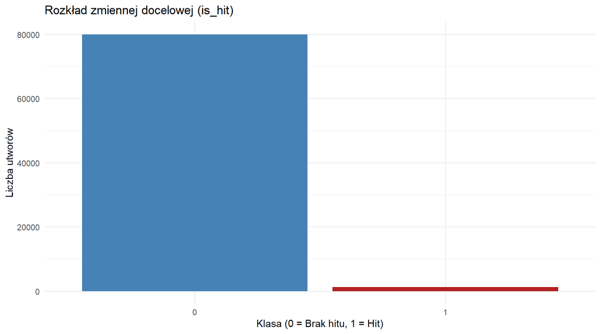

```r
ggplot(df, aes(x = is_hit, fill = is_hit)) +
  geom_bar(show.legend = FALSE) +
  scale_fill_manual(values = c("0" = "steelblue", "1" = "firebrick")) +
  theme_minimal() +
  labs(title = "Rozkład zmiennej docelowej (is_hit)",
       x = "Klasa (0 = Brak hitu, 1 = Hit)",
       y = "Liczba utworów")
```

**2. Macierz korelacji predyktorów numerycznych:**

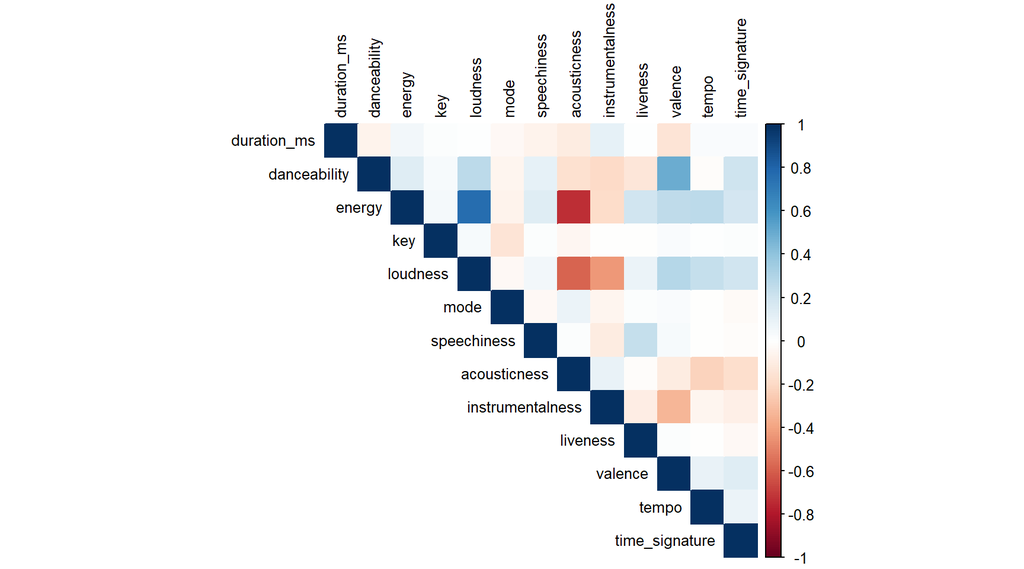

```r
numeric_cols <- df %>%
  select(where(is.numeric))

corr_matrix <- cor(numeric_cols, use = "complete.obs")

corrplot(corr_matrix,
         method = "color",
         type = "upper",
         tl.col = "black",
         tl.cex = 0.8)
```

**Wniosek:** Macierz ujawnia kilka kluczowych zależności strukturalnych. Najsilniejsza jest dodatnia korelacja między energy a loudness (r ≈ 0.76), co potwierdza, że głośność jest technicznym komponentem postrzeganej energii. Z kolei ich ujemna korelacja z acousticness odzwierciedla różnicę między instrumentami akustycznymi a współczesną produkcją elektroniczną. Z perspektywy modelowania, wysoka współliniowość predysponuje do użycia algorytmów drzewiastych, które są na nią odporne.

**3. Redukcja wymiarów (PCA):**

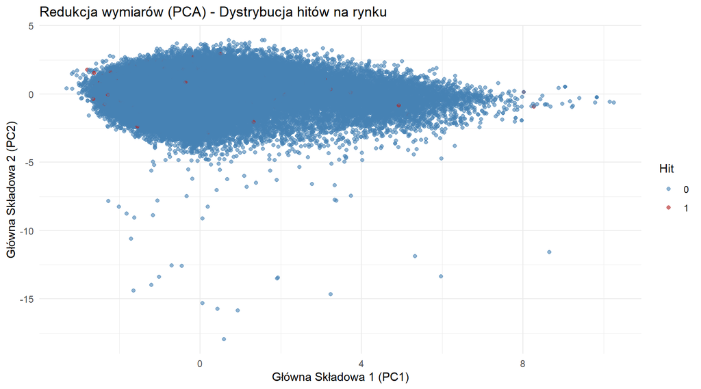

```r
pca_rec <- recipe(~ ., data = df %>% select(where(is.numeric), is_hit)) %>%
  step_normalize(all_numeric_predictors()) %>%
  step_pca(all_numeric_predictors(), num_comp = 2)

pca_prep <- prep(pca_rec)
pca_data <- bake(pca_prep, new_data = NULL)

ggplot(pca_data, aes(x = PC1, y = PC2, color = is_hit)) +
  geom_point(alpha = 0.6, size = 1.5) +
  scale_color_manual(values = c("0" = "steelblue", "1" = "firebrick")) +
  theme_minimal() +
  labs(title = "Redukcja wymiarów (PCA) - Dystrybucja hitów na rynku",
       x = "Główna Składowa 1 (PC1)",
       y = "Główna Składowa 2 (PC2)",
       color = "Hit")
```

**Wniosek:** Klasa hitów (czerwone punkty) nie tworzy zwartego, separowalnego skupiska, lecz pokrywa się niemal całkowicie z przestrzenią utworów przeciętnych. Oznacza to, że pojedyncze parametry akustyczne nie wystarczą do separacji, a granica decyzyjna jest wysoce nieliniowa. Jest to kolejny argument uzasadniający zastosowanie algorytmów zespołowych (Random Forest, XGBoost).

## 6 Przygotowanie danych do dalszego procesu modelowania

Przygotowanie danych do uczenia maszynowego zrealizowano z wykorzystaniem ekosystemu tidymodels w trzech fazach:

- **Podział zbioru:** Dane podzielono na zbiór treningowy (80%) i testowy (20%) z podziałem warstwowym (stratified split) ze względu na zmienną `is_hit`, co gwarantuje zachowanie proporcji klas w obu zbiorach.
- **Transformacja predyktorów:** Receptura transformacji (recipe) obejmuje kodowanie One-Hot Encoding dla predyktorów kategorycznych (np. `track_genre`) oraz standaryzację (centrowanie i skalowanie) zmiennych numerycznych. Zmienna logiczna `explicit` została wcześniej przekształcona na typ numeryczny.
- **Balansowanie klas:** Do receptury włączono krok SMOTE (Synthetic Minority Over-sampling Technique), który generuje syntetyczne obserwacje klasy mniejszościowej wyłącznie na zbiorze treningowym. Zbiór testowy pozostaje celowo niezmieniony, aby ocena odzwierciedlała realne, niezbalansowane warunki.

```r
df <- df %>%
  mutate(explicit = as.numeric(explicit))

set.seed(42)

data_split <- initial_split(df, prop = 0.8, strata = is_hit)
train_data <- training(data_split)
test_data <- testing(data_split)

rec <- recipe(is_hit ~ ., data = train_data) %>%
  step_dummy(all_nominal_predictors()) %>%
  step_normalize(all_numeric_predictors()) %>%
  step_smote(is_hit)

prep_rec <- prep(rec)

train_processed <- bake(prep_rec, new_data = NULL)
test_processed <- bake(prep_rec, new_data = test_data)

cat("Wymiary zbioru treningowego:", dim(train_processed)[1], "wierszy ×",
    dim(train_processed)[2], "kolumn\n\nRozkład klas po SMOTE:\n")
```

```
## Wymiary zbioru treningowego: 128074 wierszy × 127 kolumn
##
## Rozkład klas po SMOTE:
```

```r
print(table(train_processed$is_hit))
```

```
##
##     0     1
## 64037 64037
```

```r
knitr::kable(
  head(train_processed[, 1:8]),
  caption = "Pierwsze wiersze przetworzonego zbioru treningowego (wybrane kolumny)",
  digits  = 3
)
```

Pierwsze wiersze przetworzonego zbioru treningowego (wybrane kolumny)

| duration_ms | explicit | danceability | energy | key | loudness | mode | speechiness |
| --- | --- | --- | --- | --- | --- | --- | --- |
| -0.004 | -0.306 | 0.657 | -0.673 | -1.203 | 0.349 | -1.317 | 0.463 |
| -0.727 | -0.306 | -0.784 | -1.815 | -1.203 | -1.634 | 0.759 | -0.108 |
| -0.260 | -0.306 | -1.650 | -2.227 | -1.484 | -1.875 | 0.759 | -0.450 |
| -0.151 | -0.306 | 0.724 | -0.595 | 0.203 | -0.040 | 0.759 | 0.138 |
| -0.015 | -0.306 | -0.857 | -1.888 | -0.921 | -0.043 | 0.759 | -0.457 |
| 0.106 | -0.306 | 0.809 | -0.739 | 1.609 | -0.139 | 0.759 | -0.404 |

**Wniosek:** Po zastosowaniu SMOTE zbiór treningowy zawiera perfekcyjnie wyrównany rozkład klas, co zabezpiecza model przed zjawiskiem ignorowania obserwacji mniejszościowych na etapie uczenia.

## 7 Budowa, trenowanie oraz wstępne porównanie wybranych modeli uczenia maszynowego

W procesie modelowania predykcyjnego porównano trzy algorytmy klasyfikacyjne o zróżnicowanej charakterystyce:

- **Regresja Logistyczna** – model bazowy (baseline): parametryczny, interpretowalny, zakładający liniową zależność między predyktorami a logarytmem szansy.
- **Las Losowy (Random Forest)** – model zespołowy oparty na agregacji wielu drzew decyzyjnych (Bagging); odporny na multikolinearność, zdolny do modelowania nieliniowych relacji.
- **XGBoost** – algorytm Boostingu, w którym kolejne drzewa sekwencyjnie korygują błędy poprzedników; jeden z najskuteczniejszych algorytmów dla strukturalnych danych tabelarycznych.

Modele zostały wytrenowane na przetworzonym i zbalansowanym zbiorze treningowym.

```r
log_spec <- logistic_reg() %>%
  set_engine("glm") %>%
  set_mode("classification")

rf_spec <- rand_forest(trees = 100) %>%
  set_engine("ranger", importance = "impurity") %>%
  set_mode("classification")

xgb_spec <- boost_tree(trees = 100) %>%
  set_engine("xgboost") %>%
  set_mode("classification")

log_fit <- log_spec %>%
  fit(is_hit ~ ., data = train_processed)

rf_fit <- rf_spec %>%
  fit(is_hit ~ ., data = train_processed)

xgb_fit <- xgb_spec %>%
  fit(is_hit ~ ., data = train_processed)

log_preds <- predict(log_fit, new_data = test_processed) %>%
  bind_cols(predict(log_fit, new_data = test_processed, type = "prob")) %>%
  bind_cols(test_processed %>% select(is_hit))

rf_preds <- predict(rf_fit, new_data = test_processed) %>%
  bind_cols(predict(rf_fit, new_data = test_processed, type = "prob")) %>%
  bind_cols(test_processed %>% select(is_hit))

xgb_preds <- predict(xgb_fit, new_data = test_processed) %>%
  bind_cols(predict(xgb_fit, new_data = test_processed, type = "prob")) %>%
  bind_cols(test_processed %>% select(is_hit))
```

### 7.1 Wstępne porównanie modeli za pomocą kroswalidacji (5-fold CV)

Aby uzyskać stabilną ocenę modeli niezależną od losowości jednego podziału, przeprowadzono **5-krotną kroswalidację** na oryginalnym zbiorze treningowym. W każdej iteracji receptura transformacji (w tym krok SMOTE) jest stosowana *niezależnie* wyłącznie na danych treningowych danego foldu – dane walidacyjne pozostają niezmienione.

```r
# Ustawienie klasy "1" jako zdarzenia pozytywnego
options(yardstick.event_first = FALSE)

set.seed(7851)
cv_folds <- vfold_cv(train_data, v = 5, strata = is_hit)

log_wf <- workflow() %>% add_recipe(rec) %>% add_model(log_spec)
rf_wf  <- workflow() %>% add_recipe(rec) %>% add_model(rf_spec)
xgb_wf <- workflow() %>% add_recipe(rec) %>% add_model(xgb_spec)

cv_met <- metric_set(accuracy, precision, recall, f_meas, roc_auc)

log_cv <- fit_resamples(log_wf, cv_folds, metrics = cv_met)
rf_cv  <- fit_resamples(rf_wf,  cv_folds, metrics = cv_met)
xgb_cv <- fit_resamples(xgb_wf, cv_folds, metrics = cv_met)

cv_results <- bind_rows(
  collect_metrics(log_cv) %>% mutate(model = "Regresja Logistyczna"),
  collect_metrics(rf_cv)  %>% mutate(model = "Las Losowy"),
  collect_metrics(xgb_cv) %>% mutate(model = "XGBoost")
)

cv_results %>%
  select(model, .metric, mean, std_err) %>%
  mutate(
    across(c(mean, std_err), \(x) round(x, 4)),
    wynik = paste0(mean, " (±", std_err, ")")
  ) %>%
  select(model, .metric, wynik) %>%
  tidyr::pivot_wider(names_from = model, values_from = wynik) %>%
  rename(Metryka = .metric) %>%
  knitr::kable(caption = "Wyniki 5-krotnej kroswalidacji: średnia (± std. błąd)")
```

Wyniki 5-krotnej kroswalidacji: średnia (± std. błąd)

| Metryka | Regresja Logistyczna | Las Losowy | XGBoost |
| --- | --- | --- | --- |
| accuracy | 0.8346 (±0.0015) | 0.9668 (±9e-04) | 0.9701 (±7e-04) |
| f_meas | 0.9084 (±9e-04) | 0.983 (±5e-04) | 0.9848 (±4e-04) |
| precision | 0.9979 (±1e-04) | 0.99 (±2e-04) | 0.9891 (±4e-04) |
| recall | 0.8336 (±0.0016) | 0.9761 (±0.001) | 0.9804 (±0.001) |
| roc_auc | 0.9298 (±0.0023) | 0.9019 (±0.0027) | 0.888 (±0.0027) |

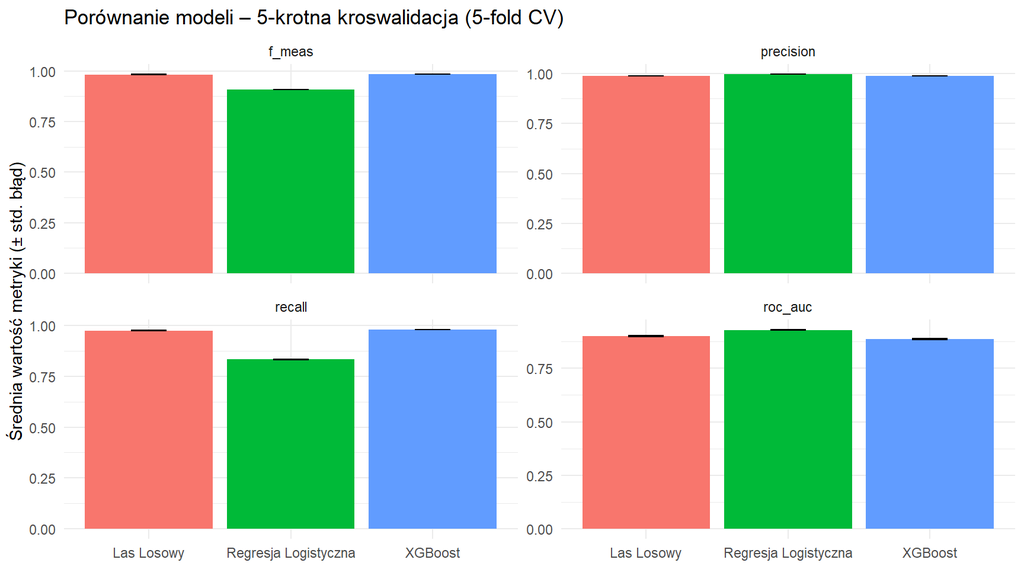

```r
cv_results %>%
  filter(.metric %in% c("f_meas", "roc_auc", "precision", "recall")) %>%
  ggplot(aes(x = model, y = mean, fill = model)) +
  geom_col(show.legend = FALSE) +
  geom_errorbar(aes(ymin = mean - std_err, ymax = mean + std_err), width = 0.25) +
  facet_wrap(~ .metric, scales = "free_y") +
  theme_minimal() +
  labs(title = "Porównanie modeli – 5-krotna kroswalidacja (5-fold CV)",
       x = NULL,
       y = "Średnia wartość metryki (± std. błąd)")
```

## 8 Ewaluacja modeli uczenia maszynowego oraz ich kalibracja

Po wytrenowaniu modeli na zbalansowanym zbiorze treningowym przeprowadzono ich ewaluację na surowym zbiorze testowym, sprawdzając zachowanie przy rzeczywistym, niezbalansowanym rozkładzie klas. Do oceny jakości klasyfikacji wykorzystano zestaw metryk: **Accuracy**, **Precision**, **Recall** oraz **F1-Score**, a także krzywe **ROC** i pole pod krzywą (**ROC-AUC**).

```r
multi_metric <- metric_set(accuracy, precision, recall, f_meas)

bind_rows(
  log_preds %>% multi_metric(truth = is_hit, estimate = .pred_class, event_level = "second") %>% mutate(Model = "Regresja Logistyczna"),
  rf_preds  %>% multi_metric(truth = is_hit, estimate = .pred_class, event_level = "second") %>% mutate(Model = "Las Losowy"),
  xgb_preds %>% multi_metric(truth = is_hit, estimate = .pred_class, event_level = "second") %>% mutate(Model = "XGBoost")
) %>%
  select(Model, Metryka = .metric, Wartość = .estimate) %>%
  mutate(Wartość = round(Wartość, 4)) %>%
  tidyr::pivot_wider(names_from = Metryka, values_from = Wartość) %>%
  knitr::kable(caption = "Metryki klasyfikacji na zbiorze testowym")
```

Metryki klasyfikacji na zbiorze testowym

| Model | accuracy | precision | recall | f_meas |
| --- | --- | --- | --- | --- |
| Regresja Logistyczna | 0.8317 | 0.0723 | 0.8268 | 0.1330 |
| Las Losowy | 0.9651 | 0.2082 | 0.4409 | 0.2828 |
| XGBoost | 0.9675 | 0.2097 | 0.3898 | 0.2727 |

```r
bind_rows(
  log_preds %>% roc_auc(truth = is_hit, .pred_1, event_level = "second") %>% mutate(Model = "Regresja Logistyczna"),
  rf_preds  %>% roc_auc(truth = is_hit, .pred_1, event_level = "second") %>% mutate(Model = "Las Losowy"),
  xgb_preds %>% roc_auc(truth = is_hit, .pred_1, event_level = "second") %>% mutate(Model = "XGBoost")
) %>%
  select(Model, `ROC-AUC` = .estimate) %>%
  mutate(`ROC-AUC` = round(`ROC-AUC`, 4)) %>%
  knitr::kable(caption = "Wartości ROC-AUC na zbiorze testowym")
```

Wartości ROC-AUC na zbiorze testowym

| Model | ROC-AUC |
| --- | --- |
| Regresja Logistyczna | 0.9197 |
| Las Losowy | 0.8927 |
| XGBoost | 0.8862 |

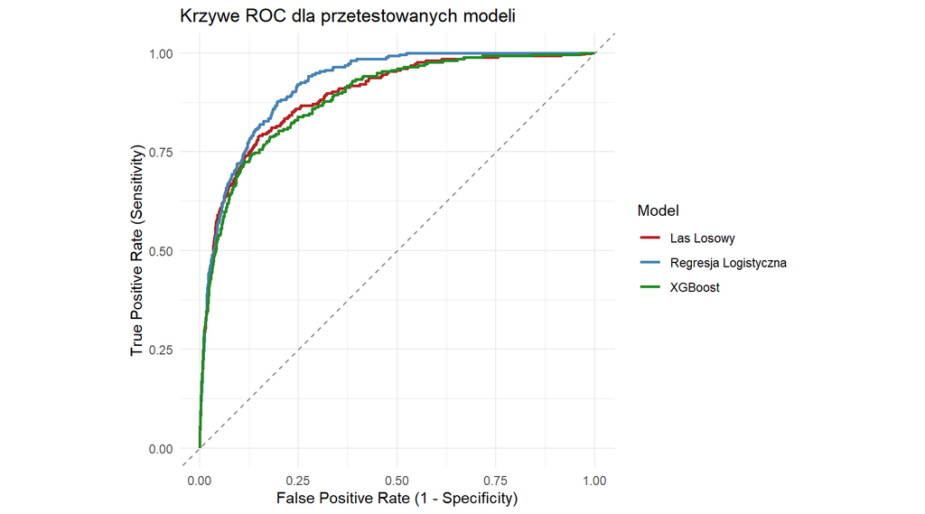

```r
log_roc <- log_preds %>% roc_curve(truth = is_hit, .pred_1, event_level = "second") %>% mutate(model = "Regresja Logistyczna")
rf_roc  <- rf_preds  %>% roc_curve(truth = is_hit, .pred_1, event_level = "second") %>% mutate(model = "Las Losowy")
xgb_roc <- xgb_preds %>% roc_curve(truth = is_hit, .pred_1, event_level = "second") %>% mutate(model = "XGBoost")

bind_rows(log_roc, rf_roc, xgb_roc) %>%
  ggplot(aes(x = 1 - specificity, y = sensitivity, color = model)) +
  geom_path(linewidth = 1) +
  geom_abline(lty = 2, color = "gray50") +
  coord_equal() +
  theme_minimal() +
  labs(title = "Krzywe ROC dla przetestowanych modeli",
       x     = "False Positive Rate (1 - Specificity)",
       y     = "True Positive Rate (Sensitivity)",
       color = "Model") +
  scale_color_manual(values = c(
    "Regresja Logistyczna" = "steelblue",
    "Las Losowy"           = "firebrick",
    "XGBoost"              = "forestgreen"
  ))
```

[figure not shown]

```r
threshold_data <- rf_preds %>%
  threshold_perf(truth = is_hit, estimate = .pred_1,
                 thresholds = seq(0.1, 0.9, by = 0.05),
                 metrics = metric_set(f_meas))

ggplot(threshold_data, aes(x = .threshold, y = .estimate)) +
  geom_line(color = "firebrick", linewidth = 1) +
  geom_point(color = "firebrick", size = 2) +
  theme_minimal() +
  labs(title = "Optymalizacja progu odcięcia - Las Losowy",
       x = "Próg odcięcia prawdopodobieństwa (Threshold)",
       y = "Wartość metryki F1-Score")
```

### 8.1 Kalibracja prawdopodobieństw

Krzywa kalibracji (*calibration plot*) pokazuje, jak dobrze prawdopodobieństwa predykcji odpowiadają rzeczywistym częstościom obserwowanych klas. Idealnie skalibrowany model leży na linii przekątnej (prawdopodobieństwo predykowane = obserwowana częstość).

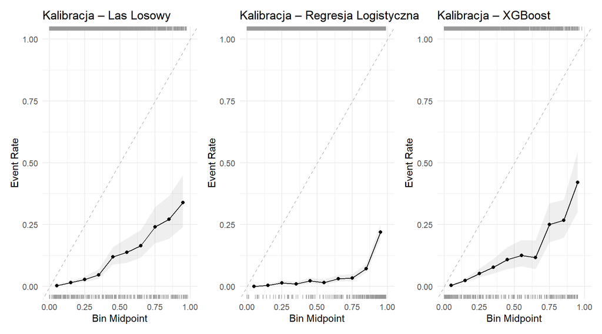

```r
cal_rf <- cal_plot_breaks(
  rf_preds, truth = is_hit, estimate = .pred_1,
  event_level = "second", num_breaks = 10
) + labs(title = "Kalibracja – Las Losowy") + theme_minimal()

cal_log <- cal_plot_breaks(
  log_preds, truth = is_hit, estimate = .pred_1,
  event_level = "second", num_breaks = 10
) + labs(title = "Kalibracja – Regresja Logistyczna") + theme_minimal()

cal_xgb <- cal_plot_breaks(
  xgb_preds, truth = is_hit, estimate = .pred_1,
  event_level = "second", num_breaks = 10
) + labs(title = "Kalibracja – XGBoost") + theme_minimal()

cal_rf + cal_log + cal_xgb
```

**Wniosek:** Zbyt agresywne nadpróbkowanie SMOTE wywołało w regresji logistycznej wyraźne przekalibrowanie – model ten systematycznie przeszacowuje szanse na to, że utwór jest hitem. Las Losowy jest dużo lepiej skalibrowany, co bezpośrednio przekłada się na jego wyższą skuteczność w praktyce biznesowej.

## 9 Przeprowadzenie analizy popełnianych błędów przez wykorzystane modele predykcyjne

Analiza macierzy pomyłek (Confusion Matrix) pozwala na precyzyjne zidentyfikowanie natury błędów popełnianych przez modele.

Głównym problemem wszystkich modeli jest wysoka liczba błędów **False Positive** (klasyfikowanie przeciętnych utworów jako hity). Zjawisko to ma głębokie uzasadnienie merytoryczne:

- **Pułapka akustyczna:** Wiele utworów jest produkowanych zgodnie z obecnymi trendami (wysoka głośność, taneczność), co sprawia, że w przestrzeni cech akustycznych są one identyczne z hitami.
- **Brakujące zmienne:** Model nie wie, czy utwór był promowany w radiu, czy artysta ma miliony fanów, ani czy piosenka stała się wiralem w mediach społecznościowych. Te “ukryte zmienne” sprawiają, że utwory o identycznych parametrach audio mają skrajnie różną popularność.
- **Błędy False Negative:** Dotyczą hitów, które “brzmią inaczej” (np. ballady akustyczne w zalewie muzyki elektronicznej) – model, ucząc się na trendach, ma trudności z wyłapaniem takich wyjątków.

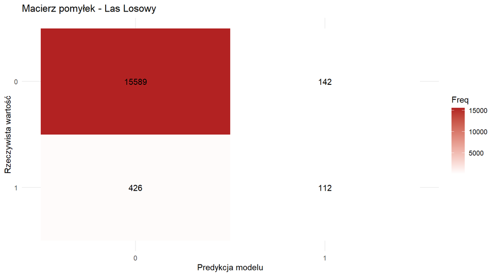

```r
rf_preds %>%
  conf_mat(truth = is_hit, estimate = .pred_class) %>%
  autoplot(type = "heatmap") +
  scale_fill_gradient(low = "white", high = "firebrick") +
  labs(title = "Macierz pomyłek - Las Losowy",
       x = "Predykcja modelu",
       y = "Rzeczywista wartość") +
  theme_minimal()
```

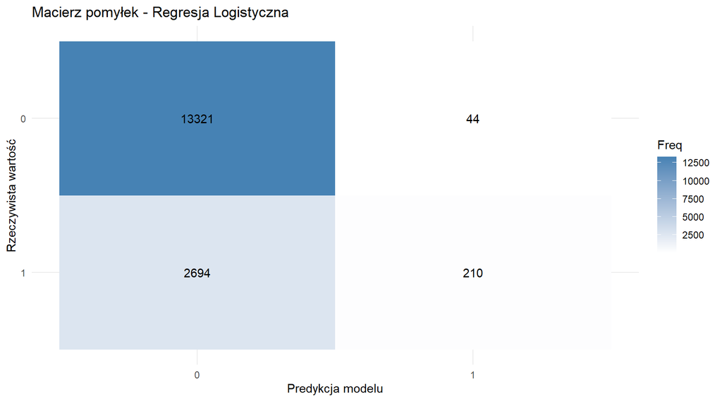

```r
log_preds %>%
  conf_mat(truth = is_hit, estimate = .pred_class) %>%
  autoplot(type = "heatmap") +
  scale_fill_gradient(low = "white", high = "steelblue") +
  labs(title = "Macierz pomyłek - Regresja Logistyczna",
       x = "Predykcja modelu",
       y = "Rzeczywista wartość") +
  theme_minimal()
```

**Wniosek:** Zestawienie macierzy pomyłek ujawnia fundamentalną różnicę w naturze błędów. Model liniowy jest niepraktyczny przez ogromną liczbę błędu typu False Positive. Las losowy jest dużo bardziej konserwatywny, lepiej identyfikując faktycznych kandydatów na hity. Błędy False Positive u Lasu Losowego to tzw. “pułapka akustyczna” – utwory, które brzmią nowocześnie i trendowo, ale nie stały się hitami przez brak wsparcia marketingowego, czego model nie jest w stanie uwzględnić.

## 10 Analiza wyjaśnialności decyzji modeli predykcyjnych

Modele oparte na drzewach decyzyjnych często określane są mianem “czarnych skrzynek”. Aby zrozumieć logikę stojącą za predykcjami wybranego modelu wiodącego (Las Losowy), przeprowadzono analizę ważności cech (**Variable Importance, VIP**). Informuje ona o tym, które zmienne najbardziej przyczyniają się do poprawy czystości węzłów w procesie budowania drzew.

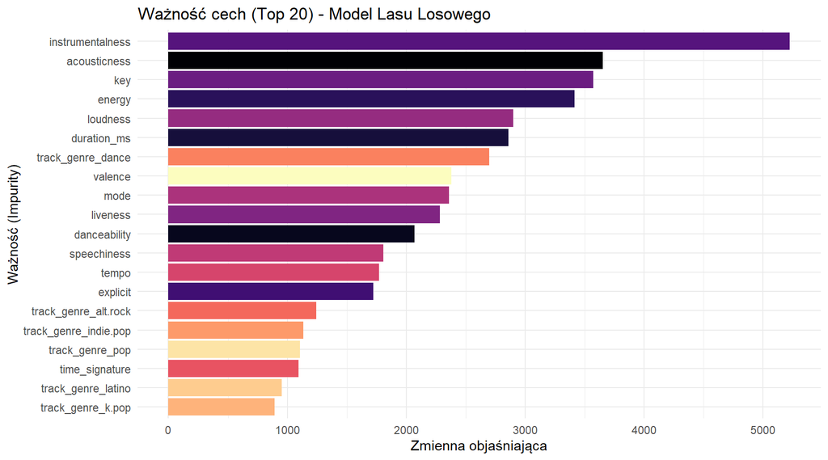

```r
vip(rf_fit$fit, num_features = 20, geom = "col",
    mapping = aes_string(fill = "Variable")) +
  theme_minimal() +
  scale_fill_viridis_d(option = "magma", guide = "none") +
  labs(title = "Ważność cech (Top 20) - Model Lasu Losowego",
       x = "Ważność (Impurity)",
       y = "Zmienna objaśniająca")
```

**Interpretacja wyników ważności cech:**

1. **Dominacja parametrów audio:** Najważniejszymi predyktorami okazały się `instrumentalness` oraz `acousticness`. Sugeruje to, że dla popularności kluczowe jest to, czy utwór ma charakter “radiowy” (wokalny, elektronicznie przetworzony). Utwory czysto instrumentalne lub o surowym, akustycznym brzmieniu rzadziej przebijają się do progu popularności >= 75.
2. **Parametry techniczne:** Wysoka pozycja `duration_ms` oraz `loudness` potwierdza rynkowe trendy – hity mają zazwyczaj określoną długość (ok. 3 minut) i są poddawane agresywnemu masteringowi (tzw. Loudness War).
3. **Marginalizacja gatunków:** Przynależność do konkretnego gatunku (`track_genre`) ma dla modelu mniejsze znaczenie niż parametry dźwiękowe. Najważniejszym gatunkiem okazał się `dance`, co jest spójne z obecną dominacją muzyki tanecznej w głównym nurcie.

## 11 Podstawowe wdrożenie modelu wybranego na podstawie przeprowadzonej ewaluacji oraz przeprowadzenie testu predykcyjnego

Stworzono profil hipotetycznego utworu popowego o parametrach dopasowanych do standardów współczesnych list przebojów (wysoka energia, taneczność, niska akustyczność).

```r
nowa_piosenka <- tibble(
  duration_ms = 210000,
  danceability = 0.85,
  energy = 0.90,
  key = 5,
  loudness = -4.5,
  mode = 1,
  speechiness = 0.05,
  acousticness = 0.10,
  instrumentalness = 0.00,
  liveness = 0.15,
  valence = 0.75,
  tempo = 120,
  time_signature = 4,
  explicit = 0,
  track_genre = "pop"
)

nowa_piosenka_processed <- bake(prep_rec, new_data = nowa_piosenka)

test_klasa <- predict(rf_fit, new_data = nowa_piosenka_processed)
test_prawdopodobienstwo <- predict(rf_fit, new_data = nowa_piosenka_processed, type = "prob")

bind_cols(test_klasa, test_prawdopodobienstwo) %>%
  rename(`Predykowana klasa` = .pred_class,
         `P(Brak hitu)`      = .pred_0,
         `P(Hit)`            = .pred_1) %>%
  mutate(across(where(is.numeric), \(x) round(x, 4))) %>%
  knitr::kable(caption = "Wynik testu wdrożeniowego – predykcja dla nowej piosenki")
```

Wynik testu wdrożeniowego – predykcja dla nowej piosenki

| Predykowana klasa | P(Brak hitu) | P(Hit) |
| --- | --- | --- |
| 1 | 0.3112 | 0.6888 |

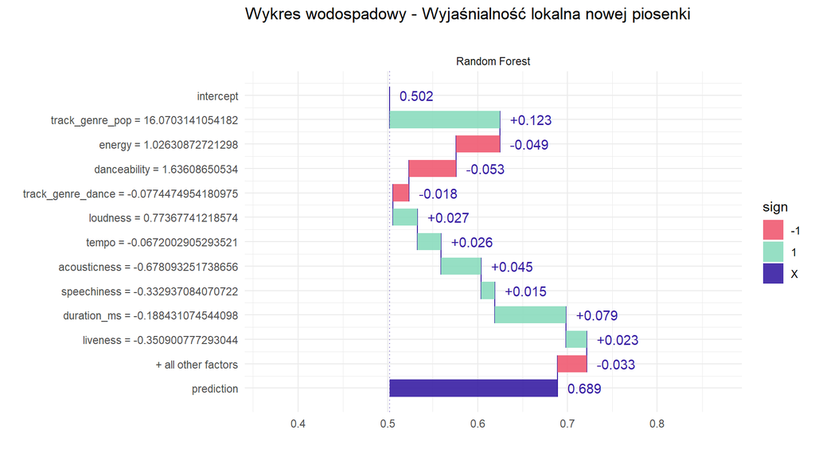

```r
rf_explainer <- explain_tidymodels(
  rf_fit,
  data = train_processed %>% select(-is_hit),
  y = as.numeric(as.character(train_processed$is_hit)),
  label = "Random Forest",
  verbose = FALSE
)

rf_parts <- predict_parts(explainer = rf_explainer,
                          new_observation = nowa_piosenka_processed,
                          type = "break_down")

plot(rf_parts) +
  ggtitle("Wykres wodospadowy - Wyjaśnialność lokalna nowej piosenki") +
  theme_minimal()
```

## 12 Podsumowanie i sformułowanie wniosków

Niniejszy projekt zrealizował pełną ścieżkę uczenia maszynowego w kontekście danych akustycznych. Podsumowując:

Ograniczenia cech akustycznych: Przewidywanie hitów nie opiera się w pełni na fizyce dźwięku. Modele takie jak Las Losowy mogą skutecznie wyłonić kandydatów o ogromnym potencjale brzmieniowym, jednak bez zmiennych ukrytych (popularność artysty, budżet reklamowy) metryki dokładności będą zawsze ograniczone (tzw. zjawisko Hit Song Science is Not Yet a Science).

Zastosowanie biznesowe: Przygotowany pipeline wraz z modułem wyjaśnialności lokalnej (DALEX) tworzy użyteczne narzędzie wspomagające dla wytwórni fonograficznych, służące jako automatyczny “filtr jakości” dla nadsyłanych demówek.

## 13 Literatura

[1] Dhanaraj, R., & Logan, B. (2005). *Automatic Prediction of Hit Songs*. Proceedings of the 6th International Symposium on Music Information Retrieval (ISMIR 2005), 488–491.

[2] Interiano, M., Kazemi, K., Wang, L., Yang, J., Yu, Z., & Komarova, N. L. (2018). *Musical trends and predictability of success in contemporary songs in and out of the top charts*. Royal Society Open Science, 5(5), 171274. https://doi.org/10.1098/rsos.171274

[3] Chen, T., & Guestrin, C. (2016). *XGBoost: A Scalable Tree Boosting System*. Proceedings of the 22nd ACM SIGKDD International Conference on Knowledge Discovery and Data Mining, 785–794. https://doi.org/10.1145/2939672.2939785

[4] Pachet, F., & Roy, P. (2008). *Hit Song Science Is Not Yet a Science*. Proceedings of the 9th International Society for Music Information Retrieval Conference (ISMIR 2008), 355–360.

[5] Chawla, N. V., Bowyer, K. W., Hall, L. O., & Kegelmeyer, W. P. (2002). *SMOTE: Synthetic Minority Over-sampling Technique*. Journal of Artificial Intelligence Research, 16, 321–357. https://doi.org/10.1613/jair.953